# WKLANDEEL FISHERIES DESCRIPTIONS

Jan-Dag Pohlmann

05-16-2024

## DATA AVAILABILITY

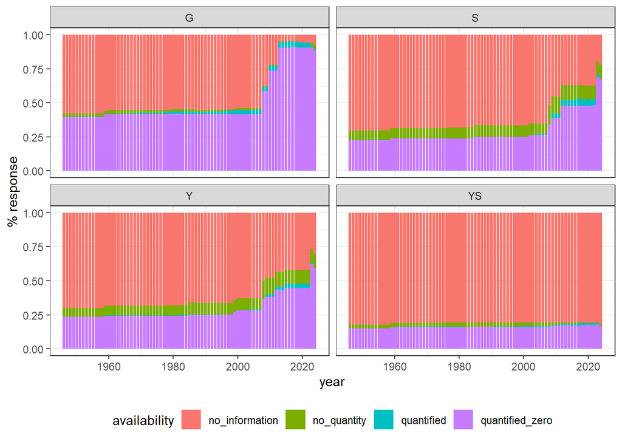

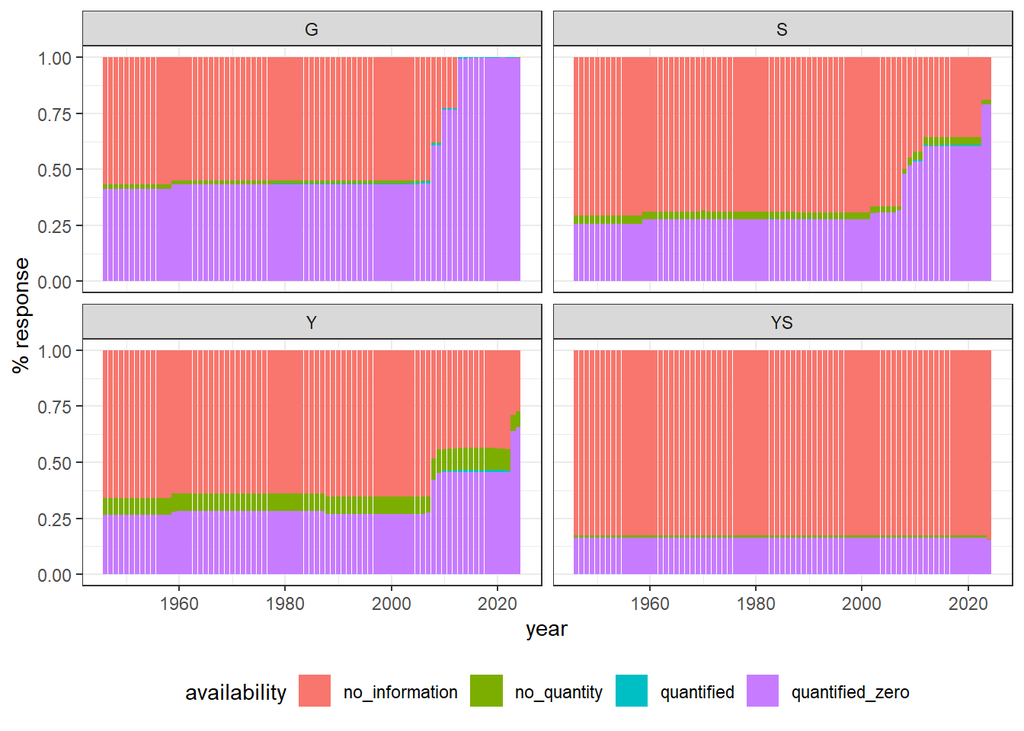

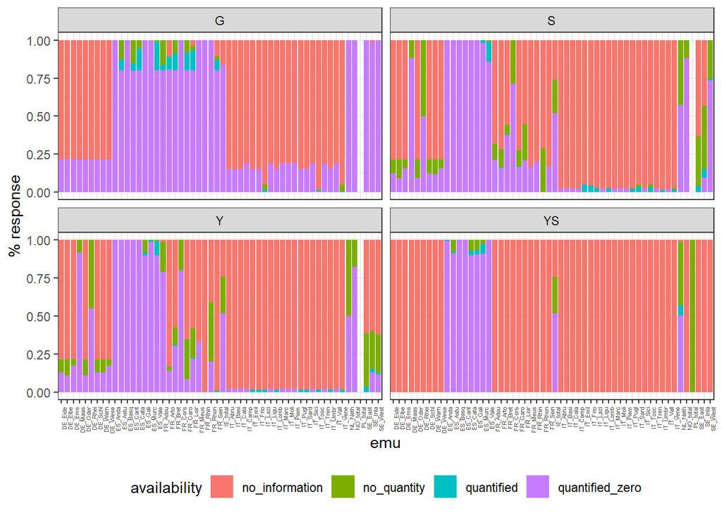

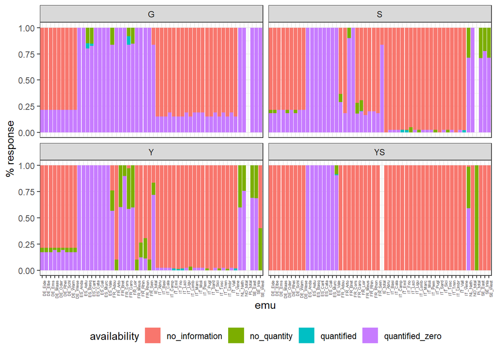

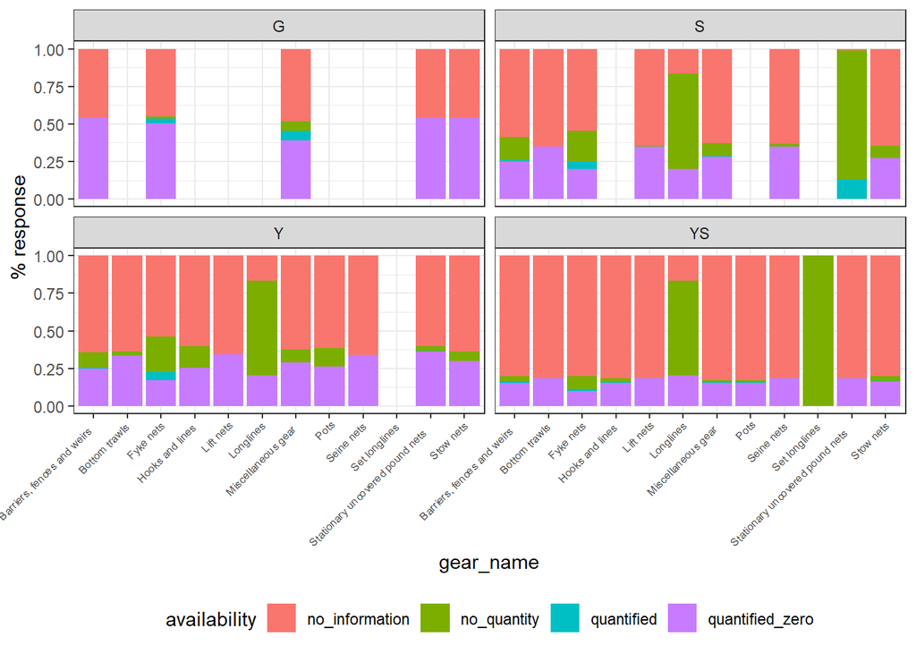

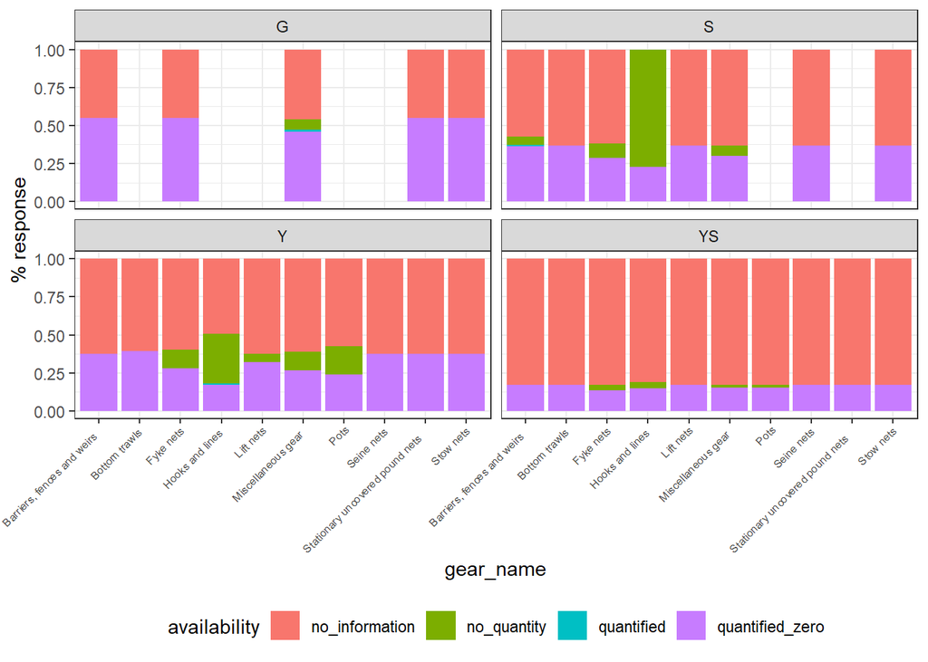

Fig. 1: Data availability of commercial and recreational landings expressed as percentage of rows by year, EMU and gear type. Each row represents data availability for a given life stage per EMU, gear type and year. Data was reported for all possible factor combinations of gear_type and year per EMU. Note, that EMUs are not weighted by size, i.e. countries with many small EMUs will have more rows and hence weight than countries with few large EMUs (except for the “by EMU” tables). no_information = data providers have no info at all, no_quantity = known landings but no quantification, quantified_zero = known zero landings, quantified = landings are quantified (either as a single value or upper/lower uncertainty margin)

## REPORTED WKLANDEEL (UPPER/LOWER BOUNDARY AVAILABLE) vs LANDINGS FROM WGEEL DATABASE

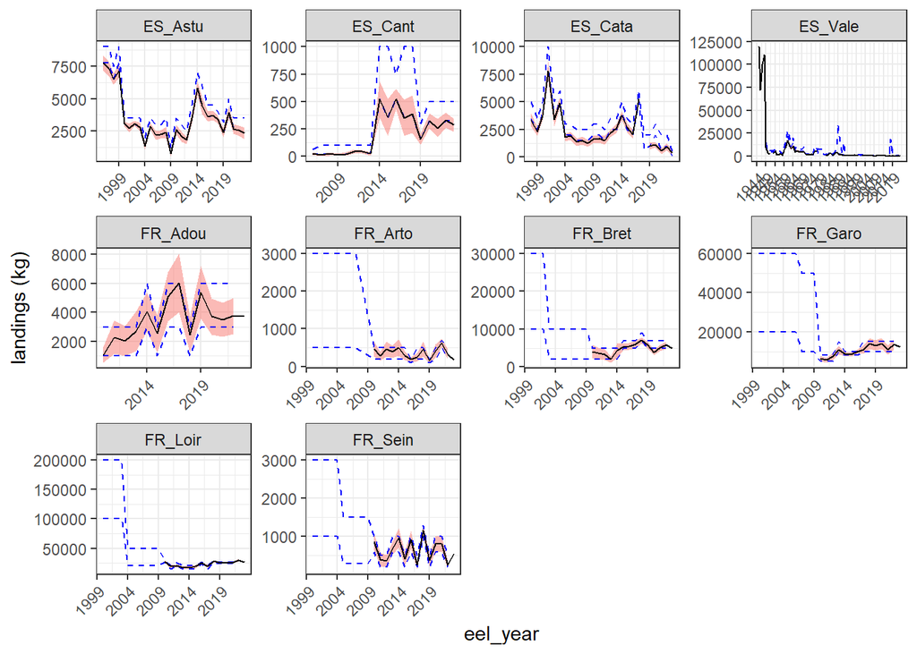

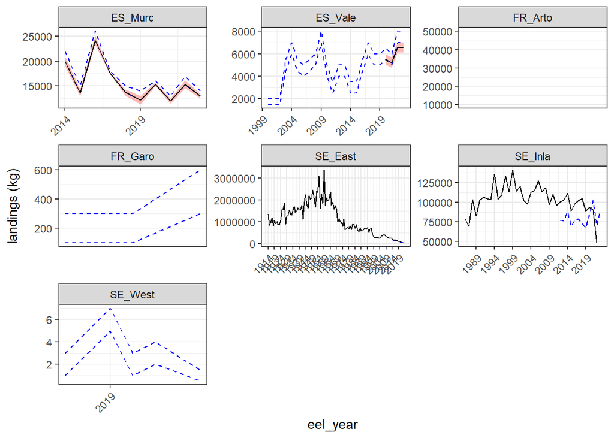

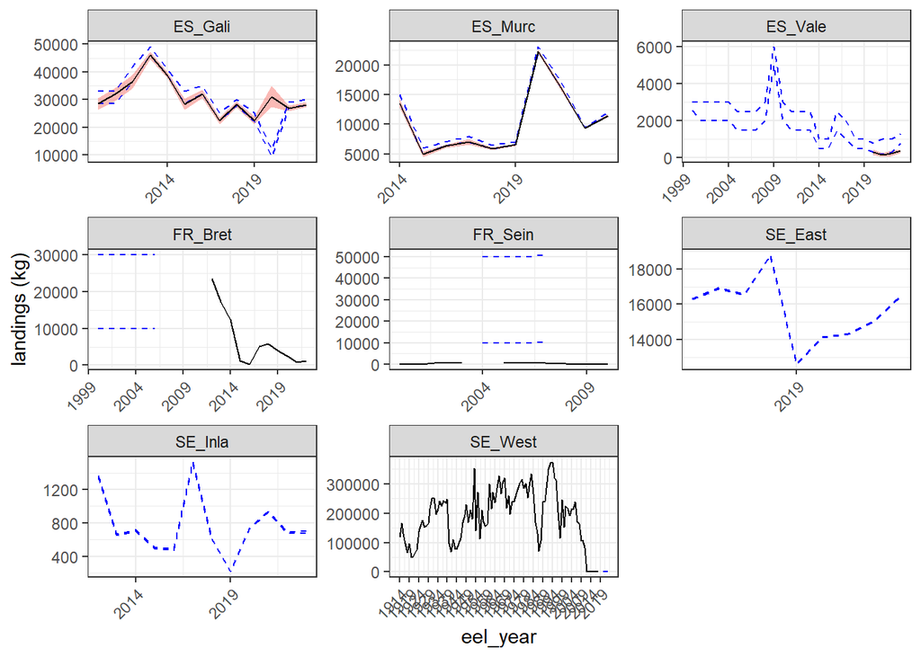

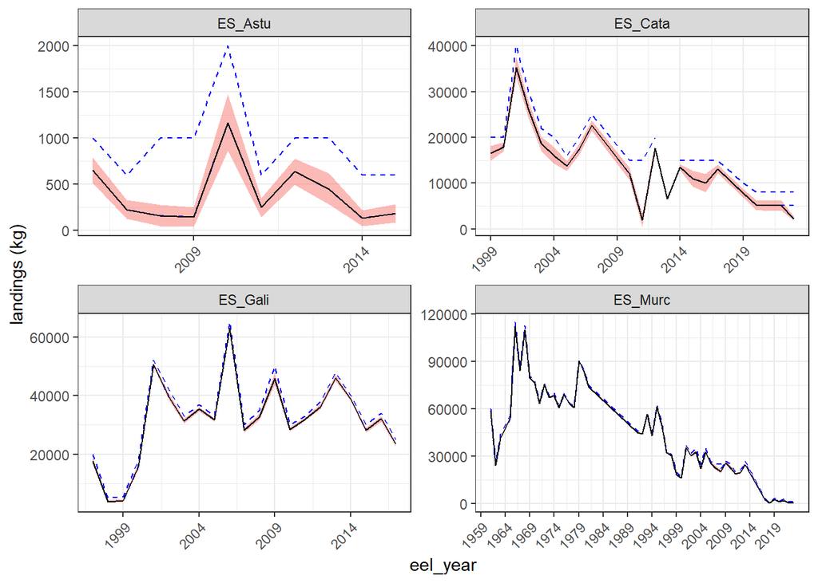

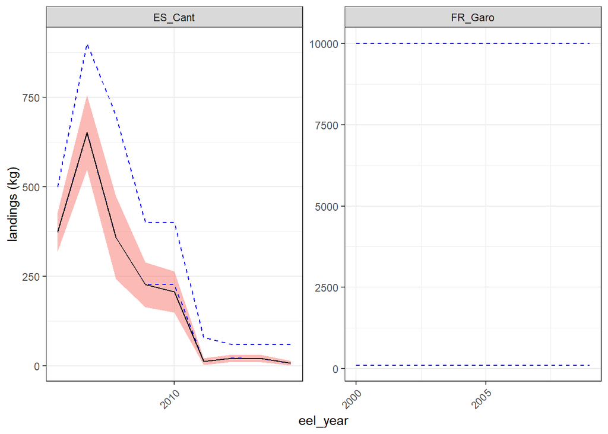

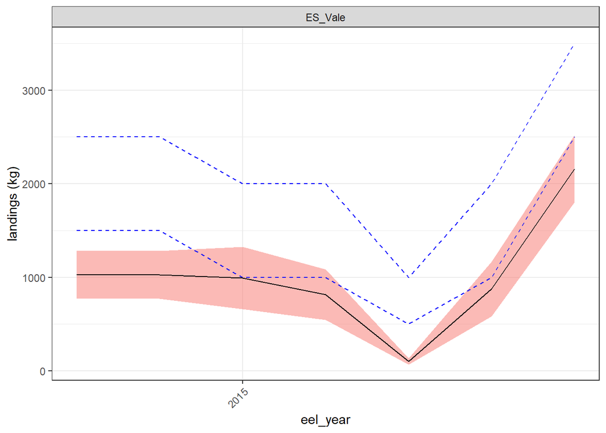

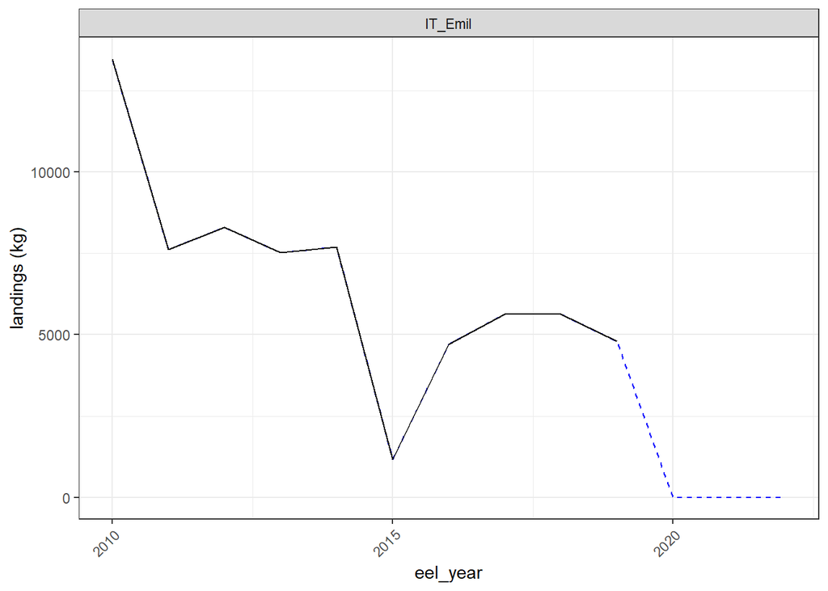

Fig. 2: Comparison of landings values from the WGEEL db with values where an upper and lower boundary (i.e. uncertainty) was reported to WKLANDEEL for at least one gear type. Comparisons are made by EMU and life stages and seperated by commercial and recreational fisheries. Black line = landings from WGEEL db, dashed blue line = reported raw upper/lower boundary (sum of all gears for the respective life stage and year), red ribbon = upper/lower boundary was scaled up/down to the dimension of the reported value in WGEEL db (e.g. uncertainty was reported for a specific gear type while an unquantified fishery was reported as well; hence, the implicit assumption is that uncertainty is similar between different gears). Note, that the sum of all reported gear types is possibly lower than the total (as reported to WGEEL) if landings are not quantified for every gear type used.  
## REPORTED WKLANDEEL (SINGLE VALUE) VS REPORTED WGEEL DATABASE

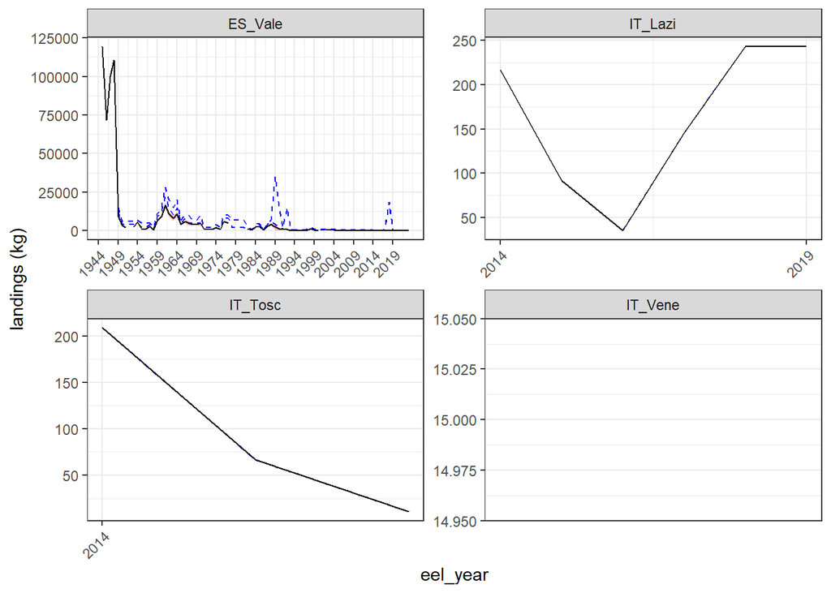

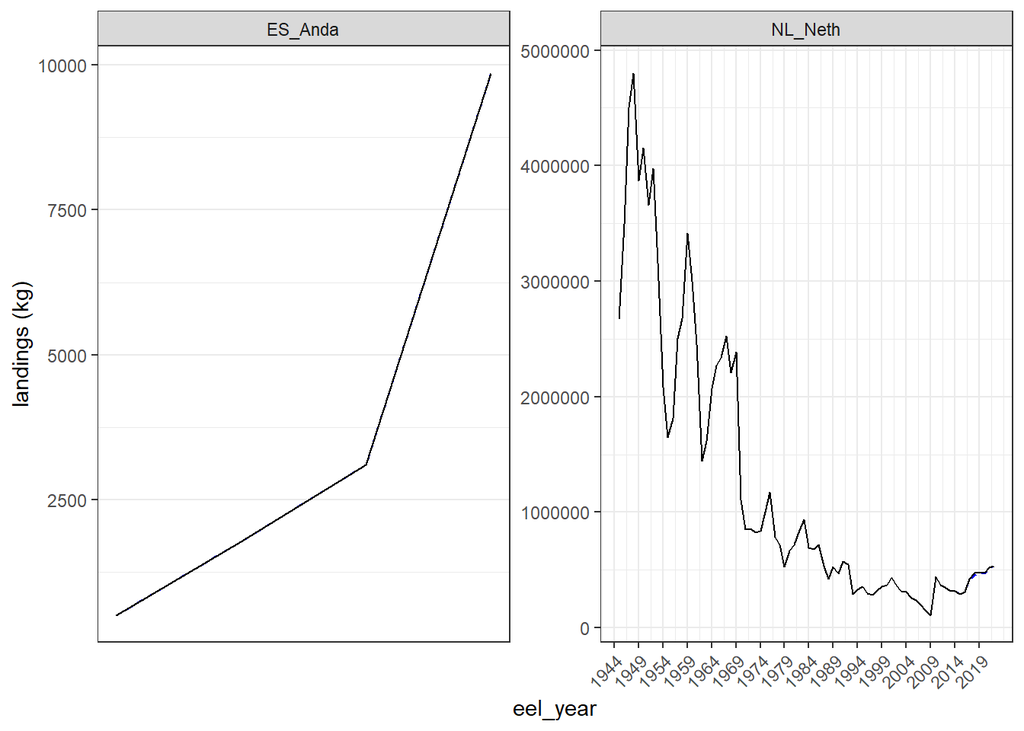

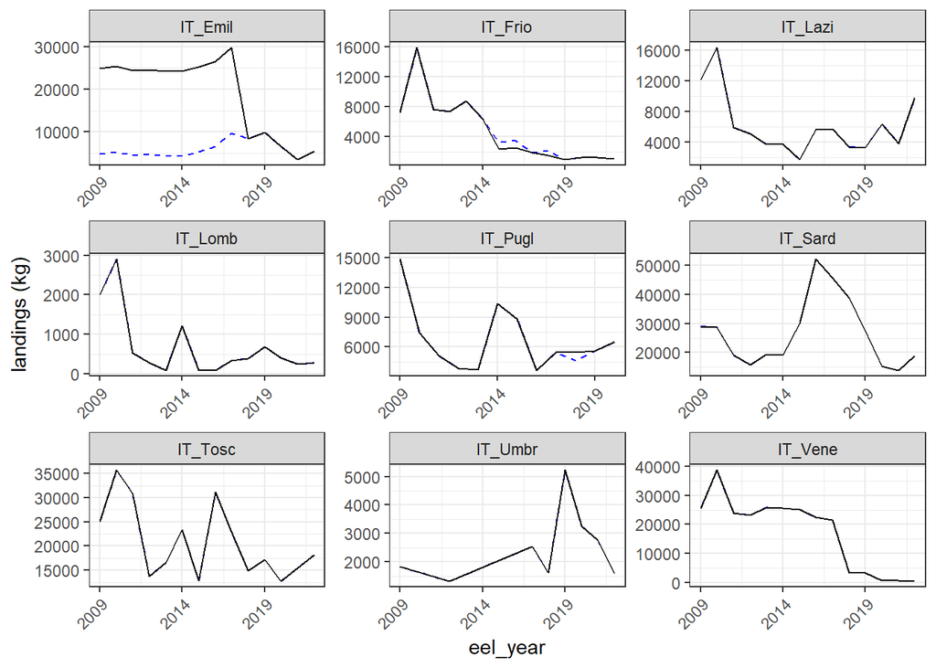

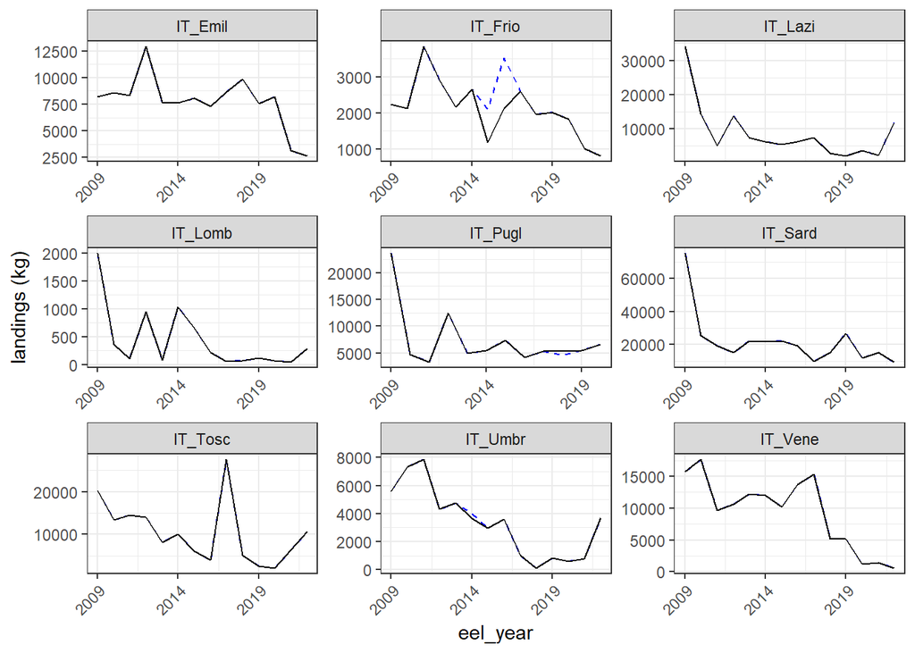

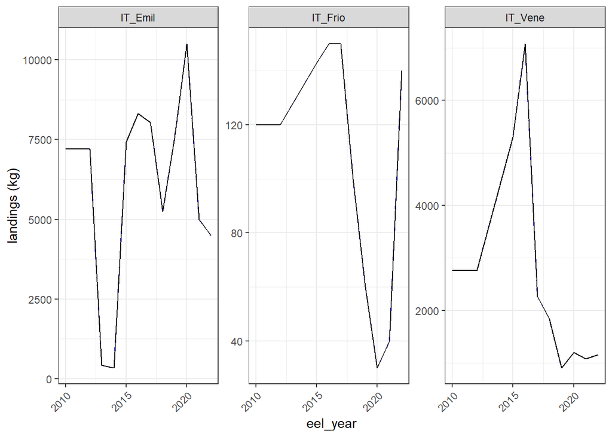

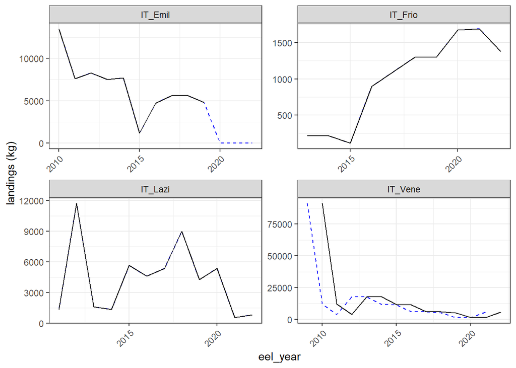

Fig. 3: Comparison of landings values from the WGEEL db with values a single value (i.e. no uncertaint) was reported to WKLANDEEL for at least one gear type. Comparisons are made by EMU and life stages and seperated by commercial and recreational fisheries. Black line = landings from WGEEL db, dashed blue line = sum of all landings for a given year and life stage as reported to WKLANDEEL. Note, that the sum of all reported gear types is possibly lower than the total (as reported to WGEEL) if landings are not quantified for every gear type used.

## CUMULATIVE UNCERTAINTIES

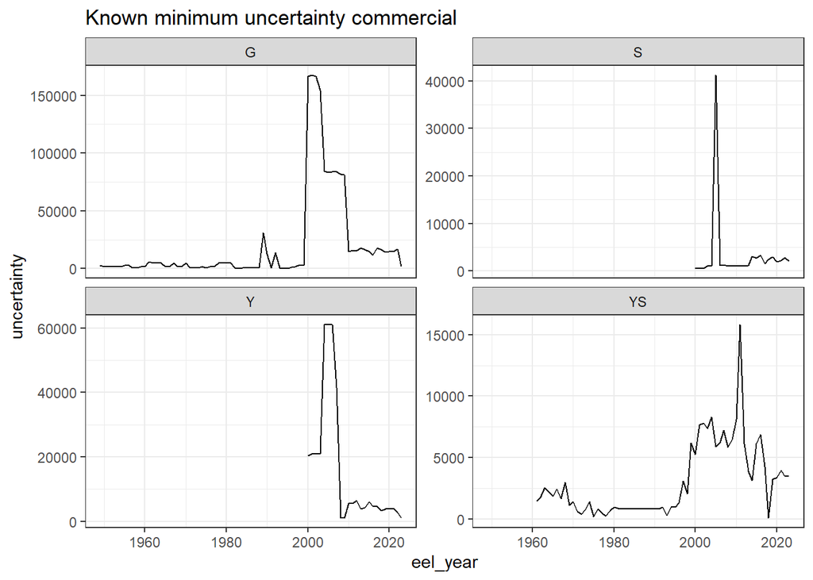

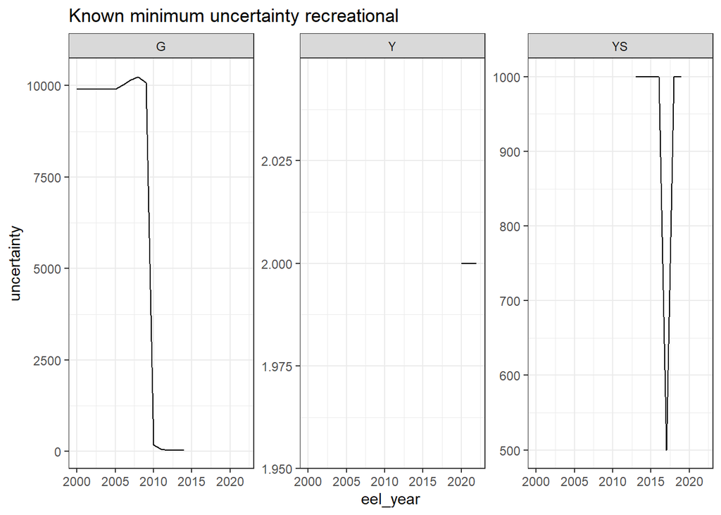

Fig 4: Known minimum uncertinty by lifestage; represented as the sum of differences between upper and lower boundary from all gear types and EMUs where respective data was reported.